# Tenis Markdown

Benjamin Esquinca

2023-01-11

## About the data.

### Introduction.

This database contains information on tennis matches in a period from 2000 to 2016.

On this occasion, I will analyze the behavior of the players in which I will determine: The cities played, the players, the field conditions, and the years played.

In addition to that, the Igaming agencies will also be added with the predictions they had before the matches, to determine which is the best agency to go to bet.

#### Load libraries

```r
library(dplyr)
library(RSQLite)
library(grid)
library(gridExtra)
```

```r
library(ggExtra)
library(cowplot)
library(tidyverse)
library(ggvis)
library(shiny)
library(DT)
library(stringr)
library(knitr)
library(kableExtra)
library(readr)
library(reshape2)
library(readr)
Data <- read_csv("Data.csv")
View(Data)
```

```r
#Converting the Rank variables into numeric variables
Data$LRank=as.numeric(Data$LRank)
Data$LPts=as.numeric(Data$LPts)
#Formatting Date to extract Season Info
Data$Date=as.Date(Data$Date,format='%d/%m/%Y')
Data$Season=as.numeric(format(Data$Date,"%Y"))

Data %>%
  mutate(Winner = gsub(" $", "", Winner), Loser = gsub(" $", "", Loser))
```

```
## # A tibble: 46,652 × 55
##      ATP Location Tournam…¹ Date       Series Court Surface Round Best …² Winner
##    <dbl> <chr>    <chr>     <date>     <chr>  <chr> <chr>   <chr>   <dbl> <chr>
##  1     1 Adelaide Australi… 2000-01-03 Inter… Outd… Hard    1st …       3 Dosed…
##  2     1 Adelaide Australi… 2000-01-03 Inter… Outd… Hard    1st …       3 Enqvi…
##  3     1 Adelaide Australi… 2000-01-03 Inter… Outd… Hard    1st …       3 Escud…
##  4     1 Adelaide Australi… 2000-01-03 Inter… Outd… Hard    1st …       3 Feder…
##  5     1 Adelaide Australi… 2000-01-03 Inter… Outd… Hard    1st …       3 Fromb…
##  6     1 Adelaide Australi… 2000-01-03 Inter… Outd… Hard    1st …       3 Gambi…
##  7     1 Adelaide Australi… 2000-01-03 Inter… Outd… Hard    1st …       3 Grosj…
##  8     1 Adelaide Australi… 2000-01-03 Inter… Outd… Hard    1st …       3 Henma…
##  9     1 Adelaide Australi… 2000-01-03 Inter… Outd… Hard    1st …       3 Hewit…
## 10     1 Adelaide Australi… 2000-01-03 Inter… Outd… Hard    1st …       3 Lisna…
## # … with 46,642 more rows, 45 more variables: Loser <chr>, WRank <dbl>,
## #   LRank <dbl>, W1 <dbl>, L1 <dbl>, W2 <dbl>, L2 <dbl>, W3 <dbl>, L3 <dbl>,
## #   W4 <dbl>, L4 <dbl>, W5 <dbl>, L5 <dbl>, Wsets <dbl>, Lsets <dbl>,
## #   Comment <chr>, CBW <dbl>, CBL <dbl>, GBW <dbl>, GBL <dbl>, IWW <dbl>,
## #   IWL <dbl>, SBW <dbl>, SBL <dbl>, B365W <dbl>, B365L <dbl>, `B&WW` <dbl>,
## #   `B&WL` <dbl>, EXW <dbl>, EXL <dbl>, PSW <dbl>, PSL <dbl>, WPts <dbl>,
## #   LPts <dbl>, UBW <dbl>, UBL <dbl>, LBW <dbl>, LBL <dbl>, SJW <dbl>, …
```

```r
summary(Data)
```

```
##       ATP          Location          Tournament             Date
##  Min.   : 1.00   Length:46652       Length:46652       Min.   :2000-01-03
##  1st Qu.:19.00   Class :character   Class :character   1st Qu.:2004-01-06
##  Median :33.00   Mode  :character   Mode  :character   Median :2008-01-14
##  Mean   :32.93                                         Mean   :2008-02-20
##  3rd Qu.:49.00                                         3rd Qu.:2012-05-03
##  Max.   :69.00                                         Max.   :2016-09-25
##
##     Series             Court             Surface             Round
##  Length:46652       Length:46652       Length:46652       Length:46652
##  Class :character   Class :character   Class :character   Class :character
##  Mode  :character   Mode  :character   Mode  :character   Mode  :character
##
##
##
##
##     Best of          Winner             Loser               WRank
##  Min.   :-1.000   Length:46652       Length:46652       Min.   :   1.00
##  1st Qu.: 3.000   Class :character   Class :character   1st Qu.:  17.00
##  Median : 3.000   Mode  :character   Mode  :character   Median :  41.00
##  Mean   : 3.374                                         Mean   :  59.06
##  3rd Qu.: 3.000                                         3rd Qu.:  77.00
##  Max.   : 5.000                                         Max.   :1890.00
##                                                         NA's   :16
##      LRank               W1              L1              W2
##  Min.   :   1.00   Min.   :0.000   Min.   :0.000   Min.   :0.000
##  1st Qu.:  35.00   1st Qu.:6.000   1st Qu.:3.000   1st Qu.:6.000
##  Median :  66.00   Median :6.000   Median :4.000   Median :6.000
##  Mean   :  94.08   Mean   :5.793   Mean   :4.043   Mean   :5.773
##  3rd Qu.: 105.00   3rd Qu.:6.000   3rd Qu.:6.000   3rd Qu.:6.000
##  Max.   :7380.00   Max.   :7.000   Max.   :7.000   Max.   :7.000
##  NA's   :98        NA's   :229     NA's   :229     NA's   :690
##        L2              W3              L3              W4
##  Min.   :0.000   Min.   :0.000   Min.   :0.000   Min.   :0.00
##  1st Qu.:2.000   1st Qu.:6.000   1st Qu.:2.000   1st Qu.:6.00
##  Median :4.000   Median :6.000   Median :4.000   Median :6.00
##  Mean   :3.854   Mean   :6.018   Mean   :3.593   Mean   :5.78
##  3rd Qu.:6.000   3rd Qu.:6.000   3rd Qu.:5.000   3rd Qu.:6.00
##  Max.   :7.000   Max.   :7.000   Max.   :7.000   Max.   :7.00
##  NA's   :689     NA's   :25287   NA's   :25287   NA's   :42426
```

[output cut: 57 more lines]

```
##  Min.   : 1.000   Min.   : 1.010   Min.   : 1.010   Min.   :    1.01
##  1st Qu.: 1.220   1st Qu.: 1.730   1st Qu.: 1.270   1st Qu.:    1.86
##  Median : 1.500   Median : 2.630   Median : 1.560   Median :    2.85
##  Mean   : 1.796   Mean   : 3.559   Mean   : 1.992   Mean   :    9.82
##  3rd Qu.: 2.000   3rd Qu.: 4.000   3rd Qu.: 2.200   3rd Qu.:    4.74
##  Max.   :19.000   Max.   :81.000   Max.   :76.000   Max.   :42586.00
##  NA's   :31080    NA's   :31073    NA's   :29548    NA's   :29548
##       AvgW            AvgL            Season
##  Min.   : 1.01   Min.   : 1.010   Min.   :2000
##  1st Qu.: 1.22   1st Qu.: 1.750   1st Qu.:2004
##  Median : 1.48   Median : 2.600   Median :2008
##  Mean   : 1.82   Mean   : 3.707   Mean   :2008
##  3rd Qu.: 2.03   3rd Qu.: 4.090   3rd Qu.:2012
##  Max.   :23.45   Max.   :36.440   Max.   :2016
##  NA's   :29548   NA's   :29548
```

### Let’s see the cities

Within our analysis, we can see that our favorite cities are: Paris, London, New York, and Melbourne.

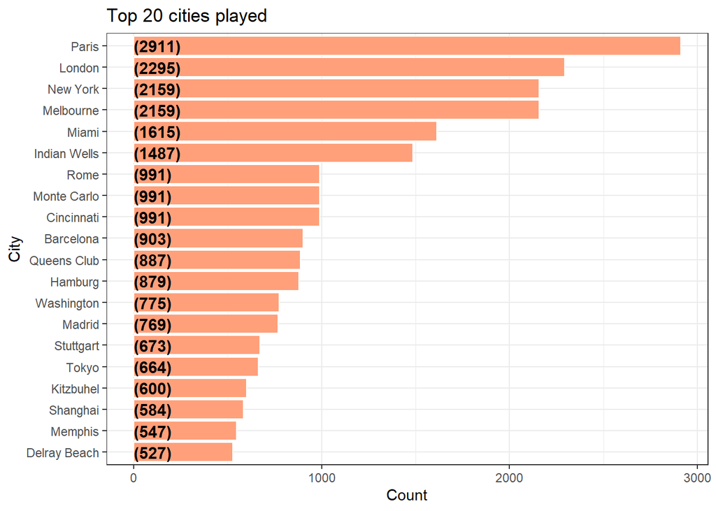

```r
fillColor = "#FFA07A"
fillColor2 = "#F1C40F"

Data %>%
  group_by(Location) %>%
  summarise(Count = n()) %>%
  arrange(desc(Count)) %>%
  ungroup() %>%
  mutate(Location = reorder(Location,Count)) %>%
  head(20) %>%

  ggplot(aes(x = Location,y = Count)) +
  geom_bar(stat='identity',colour="white", fill = fillColor) +
  geom_text(aes(x = Location, y = 1, label = paste0("(",Count,")",sep="")),
            hjust=0, vjust=.5, size = 4, colour = 'black',
            fontface = 'bold') +
  labs(x = 'City',
       y = 'Count',
       title = 'Top 20 cities played') +
  coord_flip() +
  theme_bw()
```

## Let’s analyse the players.

Let’s take de percent of winners against losers

```r
#First lets take a look at the players:

#Winners
winners = Data %>%
  group_by(Surface, Winner) %>%
  summarise(nWin = n())
#Losers
losers= Data %>%
  group_by(Surface, Loser) %>%
  summarise(nLose = n())
#Format to the new tables
colnames(winners)[2] = "Name"
colnames(losers)[2] = "Name"
```

```r
players_bySurface = merge(winners, losers, by = c("Surface", "Name"), all = T) %>%
  mutate(nWin = ifelse(is.na(nWin), 0, nWin), nLose = ifelse(is.na(nLose), 0, nLose),
         winPerc = nWin/(nWin+nLose)) %>%
  arrange(desc(winPerc))

#Some format of the percet of each player
players_overall = data.frame(players_bySurface %>%
                               group_by(Name) %>%
                               summarise(nWin = sum(nWin), nLose = sum(nLose)) %>%
                               mutate(winPerc = paste(round(nWin/(nWin+nLose)*100,2),"%",sep="")) %>%
                               filter(nWin+nLose>100) %>%
                               arrange(desc(winPerc)))
```

Let’s see our table, to have a better knowledge of what are we doing.

These tables are showing us the stats of all the players I am analyzing to get to know data such as Names, number of games won, number of games loosed, percentage of the total games won according to their games played.

```r
players_overall %>%
  select(Name, nWin, nLose, winPerc) %>%
  datatable(., options = list(pageLength = 10))
```

|  | Name | nWin | nLose | winPerc |
| --- | --- | --- | --- | --- |
| 1 | Djokovic N. | 715 | 141 | 83.53% |
| 2 | Federer R. | 1022 | 219 | 82.35% |
| 3 | Nadal R. | 779 | 171 | 82% |
| 4 | Murray A. | 571 | 174 | 76.64% |
| 5 | Agassi A. | 268 | 85 | 75.92% |
| 6 | Roddick A. | 576 | 197 | 74.51% |
| 7 | Sampras P. | 98 | 40 | 71.01% |
| 8 | Hewitt L. | 514 | 213 | 70.7% |
| 9 | Del Potro J.M. | 312 | 133 | 70.11% |
| 10 | Rafter P. | 72 | 31 | 69.9% |

[output cut: 242 more lines]

```r
df100<- players_overall %>%
  filter(nWin > 100) %>%
  arrange(desc(nWin)) %>%
  as.data.frame()
```

Now let’s see the top 20 of the players

```r
top20 <- df100 %>%
    arrange(desc(winPerc)) %>%
    head(n = 20) %>%
    as.data.frame()

top20 %>%
  select(Name, nWin, nLose, winPerc) %>%
  datatable(., options = list(pageLength = 10))
```

|  | Name | nWin | nLose | winPerc |
| --- | --- | --- | --- | --- |
| 1 | Djokovic N. | 715 | 141 | 83.53% |
| 2 | Federer R. | 1022 | 219 | 82.35% |
| 3 | Nadal R. | 779 | 171 | 82% |
| 4 | Murray A. | 571 | 174 | 76.64% |
| 5 | Agassi A. | 268 | 85 | 75.92% |
| 6 | Roddick A. | 576 | 197 | 74.51% |
| 7 | Hewitt L. | 514 | 213 | 70.7% |
| 8 | Del Potro J.M. | 312 | 133 | 70.11% |
| 9 | Raonic M. | 238 | 112 | 68% |
| 10 | Tsonga J.W. | 360 | 170 | 67.92% |

[output cut: 10 more lines]

#### About our top 20

According to our data, Federer is the player who won the most matches from 2000 through 2016 for a significant advantage. Followed by Nadal and Djokovic.

The next places at the top of the players behave with a constant gap because unlike Federer who has a bigger advantage, the next players in the table tend to have a smaller trend.

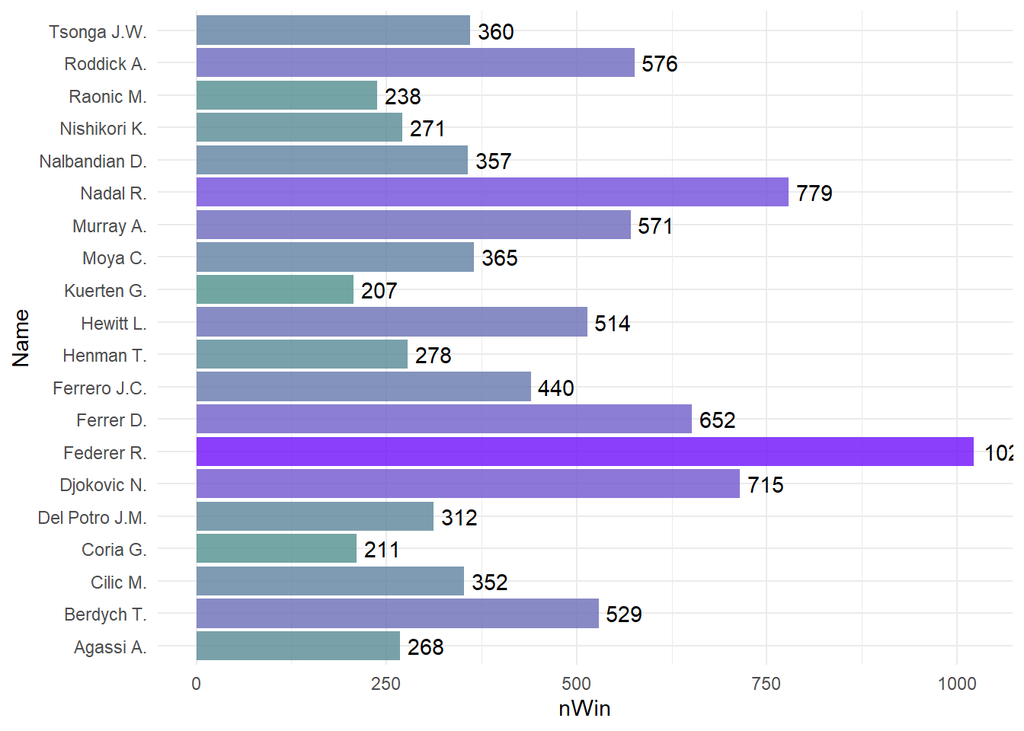

```r
top20 %>%
  ggplot(aes(y = Name , x = nWin , fill = nWin )) +
  geom_bar(stat="identity",position=position_dodge(), alpha = 0.8) + theme_minimal() +
  scale_fill_gradient(low="#4f908c",high="#6e0ff9") +  theme(legend.position="none")+
  geom_text(aes(label= nWin), hjust= -0.2)
```

#### About the surface.

Now let’s see if the type of field affects the performance of the players, to have an understanding of the field circumstances.

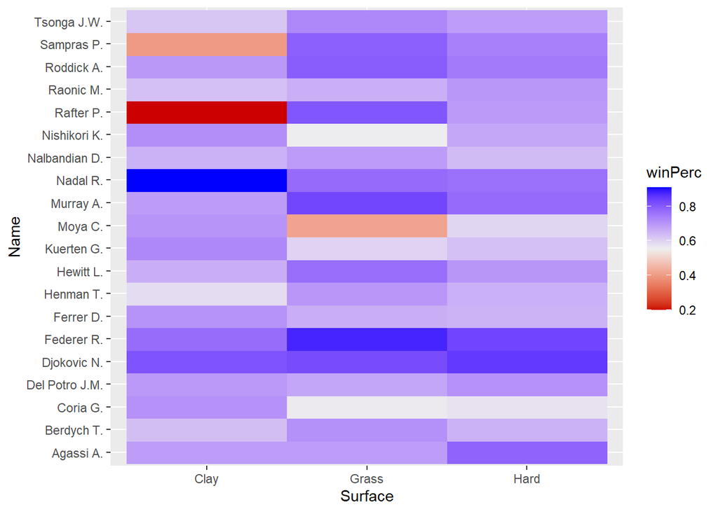

```r
ggplot(data.frame(players_bySurface %>%
                    filter (Name %in% players_overall[1:20, "Name"] & Surface != "Carpet")), aes(x = Surface, y = Name)) +
  geom_raster(aes(fill = winPerc))+
  labs(x = "Surface", y = "Name")+
  scale_fill_gradientn(colours=c("#cc0000","#eeeeee","#0000ff"))
```

## About the odds agencies.

Now we will talk about the Igaming agencies and how they have behaved over time, to know which one is best for me to invest and bet on.

I’m sure Federer will win me a couple of bucks! But let’s see which agency tends to have a better prediction of games won and lost.

First, let me create a dataframe for this analysis.

```r
agencies = Data [,12:55]
rank_agencies <- select(agencies, -3:-15)
rank_agencies2 <- select(rank_agencies, -27:-30)
rank_agencies2[3:20] <- apply(rank_agencies2[3:20], 2, round, 0)

rankagencies = rank_agencies2 [,1:27]
```

Now, I’m going to clean and manipulate some data to have a better understanding.

```r
#Let's create columns with the wins and loses of each company

#CB Win and lose odds
rankagencies$CBW_Win_Odds <- ifelse(rankagencies$WRank == rankagencies$CBW, 1, 0)
rankagencies$CB_Lose_Odds <- ifelse(rankagencies$LRank == rankagencies$CBL, 1, 0)

#GB Win and lose odds
rankagencies$GB_Win_Odds <- ifelse(rankagencies$WRank == rankagencies$GBW, 1, 0)
rankagencies$GB_Lose_Odds <- ifelse(rankagencies$LRank == rankagencies$GBL, 1, 0)

#IW Win and lose odds
rankagencies$IW_Win_Odds <- ifelse(rankagencies$WRank == rankagencies$IWW, 1, 0)
rankagencies$IW_Lose_Odds <- ifelse(rankagencies$LRank == rankagencies$IWL, 1, 0)

#SB Win and lose odds
rankagencies$SB_Win_Odds <- ifelse(rankagencies$WRank == rankagencies$SBW, 1, 0)
rankagencies$SB_Lose_Odds <- ifelse(rankagencies$LRank == rankagencies$SBL, 1, 0)

#B365 Win and lose odds
rankagencies$B365_Win_Odds <- ifelse(rankagencies$WRank == rankagencies$B365W, 1, 0)
rankagencies$B365_Lose_Odds <- ifelse(rankagencies$LRank == rankagencies$B365L, 1, 0)

#EX Win and lose odds
rankagencies$EX_Win_Odds <- ifelse(rankagencies$WRank == rankagencies$EXW, 1, 0)
rankagencies$EX_Lose_Odds <- ifelse(rankagencies$LRank == rankagencies$EXL, 1, 0)

#PS Win and lose odds
rankagencies$PS_Win_Odds <- ifelse(rankagencies$WRank == rankagencies$PSW, 1, 0)
rankagencies$PS_Lose_Odds <- ifelse(rankagencies$LRank == rankagencies$PSL, 1, 0)

#UB Win and lose odds
rankagencies$UB_Win_Odds <- ifelse(rankagencies$WRank == rankagencies$UBW, 1, 0)
rankagencies$UB_Lose_Odds <- ifelse(rankagencies$LRank == rankagencies$UBL, 1, 0)

#LB Win and lose odds
rankagencies$LB_Win_Odds <- ifelse(rankagencies$WRank == rankagencies$LBW, 1, 0)
rankagencies$LB_Lose_Odds <- ifelse(rankagencies$LRank == rankagencies$LBL, 1, 0)

#SJ Win and lose odds
rankagencies$SJ_Win_Odds <- ifelse(rankagencies$WRank == rankagencies$SJW, 1, 0)
rankagencies$SJ_Lose_Odds <- ifelse(rankagencies$LRank == rankagencies$SJL, 1, 0)
```

Okay then, lets start analyzing these.

```r
summary(rankagencies)
```

```
##      WRank             LRank              CBW              CBL
##  Min.   :   1.00   Min.   :   1.00   Min.   : 1.000   Min.   : 1.00
##  1st Qu.:  17.00   1st Qu.:  35.00   1st Qu.: 1.000   1st Qu.: 2.00
##  Median :  41.00   Median :  66.00   Median : 2.000   Median : 2.00
##  Mean   :  59.06   Mean   :  94.08   Mean   : 1.768   Mean   : 2.99
##  3rd Qu.:  77.00   3rd Qu.: 105.00   3rd Qu.: 2.000   3rd Qu.: 3.00
##  Max.   :1890.00   Max.   :7380.00   Max.   :14.000   Max.   :25.00
##  NA's   :16        NA's   :98        NA's   :29145    NA's   :29145
##       GBW             GBL             IWW             IWL
##  Min.   :1.0     Min.   : 1.00   Min.   :1.00    Min.   : 1.00
##  1st Qu.:1.0     1st Qu.: 2.00   1st Qu.:1.00    1st Qu.: 2.00
##  Median :2.0     Median : 2.00   Median :2.00    Median : 2.00
##  Mean   :1.7     Mean   : 2.41   Mean   :1.63    Mean   : 2.36
##  3rd Qu.:2.0     3rd Qu.: 3.00   3rd Qu.:2.00    3rd Qu.: 3.00
##  Max.   :8.0     Max.   :11.00   Max.   :6.00    Max.   :10.00
##  NA's   :41597   NA's   :41597   NA's   :33294   NA's   :33294
##       SBW             SBL            B365W            B365L
##  Min.   :0.00    Min.   : 0.00   Min.   : 1.000   Min.   :  1.000
##  1st Qu.:1.00    1st Qu.: 2.00   1st Qu.: 1.000   1st Qu.:  2.000
##  Median :2.00    Median : 2.00   Median : 2.000   Median :  2.000
##  Mean   :1.77    Mean   : 2.69   Mean   : 1.769   Mean   :  3.581
##  3rd Qu.:2.00    3rd Qu.: 3.00   3rd Qu.: 2.000   3rd Qu.:  4.000
##  Max.   :9.00    Max.   :13.00   Max.   :29.000   Max.   :101.000
##  NA's   :41228   NA's   :41228   NA's   :8633     NA's   :8610
##       B&WW            B&WL            EXW              EXL
##  Min.   :1.00    Min.   :1.00    Min.   : 0.000   Min.   : 1.000
##  1st Qu.:1.00    1st Qu.:2.00    1st Qu.: 1.000   1st Qu.: 2.000
##  Median :2.00    Median :2.00    Median : 2.000   Median : 2.000
##  Mean   :1.67    Mean   :2.52    Mean   : 1.743   Mean   : 3.296
##  3rd Qu.:2.00    3rd Qu.:3.00    3rd Qu.: 2.000   3rd Qu.: 4.000
##  Max.   :8.00    Max.   :9.00    Max.   :20.000   Max.   :40.000
##  NA's   :45555   NA's   :45555   NA's   :12853    NA's   :12848
##       PSW              PSL               WPts              LPts
##  Min.   : 1.000   Min.   :  1.000   Min.   :    1.0   Min.   :    1
##  1st Qu.: 1.000   1st Qu.:  2.000   1st Qu.:  628.0   1st Qu.:  487
##  Median : 2.000   Median :  3.000   Median :  994.5   Median :  724
##  Mean   : 1.867   Mean   :  4.292   Mean   : 1836.1   Mean   : 1028
##  3rd Qu.: 2.000   3rd Qu.:  4.000   3rd Qu.: 1860.0   3rd Qu.: 1118
##  Max.   :46.000   Max.   :121.000   Max.   :16950.0   Max.   :16950
##  NA's   :14923    NA's   :14923     NA's   :16204     NA's   :16256
```

[output cut: 41 more lines]

```
##  Min.   :0.000   Min.   :0       Min.   :0       Min.   :0.000
##  1st Qu.:0.000   1st Qu.:0       1st Qu.:0       1st Qu.:0.000
##  Median :0.000   Median :0       Median :0       Median :0.000
##  Mean   :0.006   Mean   :0       Mean   :0       Mean   :0.001
##  3rd Qu.:0.000   3rd Qu.:0       3rd Qu.:0       3rd Qu.:0.000
##  Max.   :1.000   Max.   :1       Max.   :1       Max.   :1.000
##  NA's   :14980   NA's   :35983   NA's   :36002   NA's   :23429
##   LB_Lose_Odds    SJ_Win_Odds     SJ_Lose_Odds
##  Min.   :0.000   Min.   :0.000   Min.   :0.000
##  1st Qu.:0.000   1st Qu.:0.000   1st Qu.:0.000
##  Median :0.000   Median :0.000   Median :0.000
##  Mean   :0.001   Mean   :0.001   Mean   :0.002
##  3rd Qu.:0.000   3rd Qu.:0.000   3rd Qu.:0.000
##  Max.   :1.000   Max.   :1.000   Max.   :1.000
##  NA's   :23459   NA's   :31083   NA's   :31097
```

```r
scores = rankagencies [,27:47]

scores %>%
  group_by(Season) %>%
  summarize(count = n())
```

```
## # A tibble: 17 × 2
##    Season count
##     <dbl> <int>
##  1   2000  2963
##  2   2001  3056
##  3   2002  2806
##  4   2003  2816
##  5   2004  2877
##  6   2005  2910
##  7   2006  2908
##  8   2007  2824
##  9   2008  2689
## 10   2009  2731
## 11   2010  2679
## 12   2011  2675
## 13   2012  2683
## 14   2013  2595
## 15   2014  2560
## 16   2015  2630
## 17   2016  2250
```

```r
Win_Ods = scores %>%
  select(Season, ends_with("Win_Odds"))

Loser_Ods = scores %>%
  select(Season, ends_with("Lose_Odds"))

summary(Win_Ods)
```

```
##      Season      CBW_Win_Odds    GB_Win_Odds     IW_Win_Odds     SB_Win_Odds
##  Min.   :2000   Min.   :0.000   Min.   :0.00    Min.   :0.00    Min.   :0.00
##  1st Qu.:2004   1st Qu.:0.000   1st Qu.:0.00    1st Qu.:0.00    1st Qu.:0.00
##  Median :2008   Median :0.000   Median :0.00    Median :0.00    Median :0.00
##  Mean   :2008   Mean   :0.025   Mean   :0.02    Mean   :0.02    Mean   :0.02
##  3rd Qu.:2012   3rd Qu.:0.000   3rd Qu.:0.00    3rd Qu.:0.00    3rd Qu.:0.00
##  Max.   :2016   Max.   :1.000   Max.   :1.00    Max.   :1.00    Max.   :1.00
##                 NA's   :29149   NA's   :41597   NA's   :33298   NA's   :41228
##  B365_Win_Odds    EX_Win_Odds     PS_Win_Odds     UB_Win_Odds
##  Min.   :0.000   Min.   :0.000   Min.   :0.000   Min.   :0
##  1st Qu.:0.000   1st Qu.:0.000   1st Qu.:0.000   1st Qu.:0
##  Median :0.000   Median :0.000   Median :0.000   Median :0
##  Mean   :0.026   Mean   :0.027   Mean   :0.027   Mean   :0
##  3rd Qu.:0.000   3rd Qu.:0.000   3rd Qu.:0.000   3rd Qu.:0
##  Max.   :1.000   Max.   :1.000   Max.   :1.000   Max.   :1
##  NA's   :8645    NA's   :12865   NA's   :14935   NA's   :35983
##   LB_Win_Odds     SJ_Win_Odds
##  Min.   :0.000   Min.   :0.000
##  1st Qu.:0.000   1st Qu.:0.000
##  Median :0.000   Median :0.000
##  Mean   :0.001   Mean   :0.001
##  3rd Qu.:0.000   3rd Qu.:0.000
##  Max.   :1.000   Max.   :1.000
##  NA's   :23429   NA's   :31083
```

```r
TotalWins = Win_Ods %>%
  group_by(Season) %>%
  summarize_all(funs(sum(., na.rm = TRUE)))
TotalLose = TotalLose = Loser_Ods %>%
  group_by(Season) %>%
  summarize_all(funs(sum(., na.rm = TRUE)))

summary(Loser_Ods)
```

```
##      Season      CB_Lose_Odds    GB_Lose_Odds    IW_Lose_Odds    SB_Lose_Odds
##  Min.   :2000   Min.   :0.000   Min.   :0.00    Min.   :0       Min.   :0.00
##  1st Qu.:2004   1st Qu.:0.000   1st Qu.:0.00    1st Qu.:0       1st Qu.:0.00
##  Median :2008   Median :0.000   Median :0.00    Median :0       Median :0.00
##  Mean   :2008   Mean   :0.005   Mean   :0.01    Mean   :0       Mean   :0.01
##  3rd Qu.:2012   3rd Qu.:0.000   3rd Qu.:0.00    3rd Qu.:0       3rd Qu.:0.00
##  Max.   :2016   Max.   :1.000   Max.   :1.00    Max.   :1       Max.   :1.00
##                 NA's   :29161   NA's   :41607   NA's   :33316   NA's   :41232
##  B365_Lose_Odds   EX_Lose_Odds    PS_Lose_Odds    UB_Lose_Odds
##  Min.   :0.000   Min.   :0.000   Min.   :0.000   Min.   :0
##  1st Qu.:0.000   1st Qu.:0.000   1st Qu.:0.000   1st Qu.:0
##  Median :0.000   Median :0.000   Median :0.000   Median :0
##  Mean   :0.005   Mean   :0.005   Mean   :0.006   Mean   :0
##  3rd Qu.:0.000   3rd Qu.:0.000   3rd Qu.:0.000   3rd Qu.:0
##  Max.   :1.000   Max.   :1.000   Max.   :1.000   Max.   :1
##  NA's   :8673    NA's   :12901   NA's   :14980   NA's   :36002
##   LB_Lose_Odds    SJ_Lose_Odds
##  Min.   :0.000   Min.   :0.000
##  1st Qu.:0.000   1st Qu.:0.000
##  Median :0.000   Median :0.000
##  Mean   :0.001   Mean   :0.002
##  3rd Qu.:0.000   3rd Qu.:0.000
##  Max.   :1.000   Max.   :1.000
##  NA's   :23459   NA's   :31097
```

```r
TotL = TotalLose %>%
  summarize_all(funs(sum(., na.rm = TRUE)))
```

#### Win odds

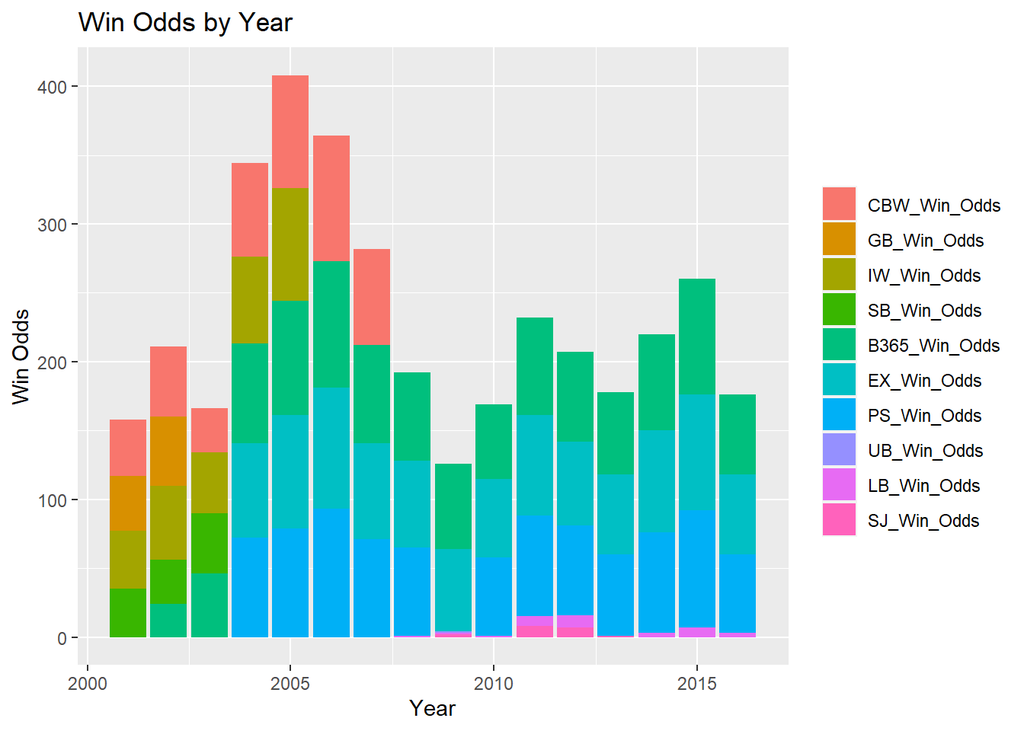

```r
Win_Ods_long <- melt(Win_Ods, id.vars = "Season")

ggplot(Win_Ods_long, aes(x = Season, y = value, fill = variable)) +
  geom_bar(stat = "identity", position = "stack") +
  ggtitle("Win Odds by Year") +
  xlab("Year") +
  ylab("Win Odds") +
  theme(legend.title=element_blank())
```

#### Top 3 win odds

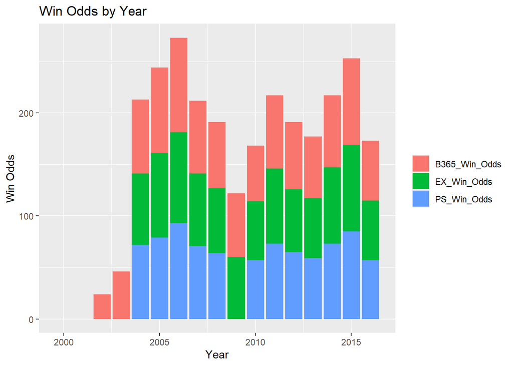

```r
Top3W = TotalWins %>%
  select(Season, B365_Win_Odds,EX_Win_Odds,PS_Win_Odds)

Top3W_long <- melt(Top3W, id.vars = "Season")

ggplot(Top3W_long, aes(x = Season, y = value, fill = variable)) +
  geom_bar(stat = "identity", position = "stack") +
  ggtitle("Win Odds by Year") +
  xlab("Year") +
  ylab("Win Odds") +
  theme(legend.title=element_blank())
```